# BTEP-R/RStudio-Intro

Drs. Sarangan Ravichandran and Randall Johnson

February 26, 2017

### Cleaning up

Before we begin, let us clean up the environment and set a working directory. This will clear all the variables and start fresh. If you want to follow on, then we suggest you to run the following lines.

```r
setwd("H:/2017/BTEP1-TidyingData")
rm(list = ls())
```

### Loading the libraries

Let us first load the libraries needed for the workshop

```r
# if you dont have tidyverse then run the following line once
# install.packages(c("tidyverse", "knitr"))
library(tidyverse)
library(knitr)
library(lubridate)
```

### Quick tour of RStudio

We will be using RStudio as the main software for the workshp. Let us do a quick live tour of RStudio. We will cover the following useful options accessible through RStudio:

#### Tools

- Pane (View –> Pane); Option that we are using is “Console on Right”
- Tools –> Install Packages
- Tools –> Global Options
- Session –> Set Working Directory
- Optons –> R Session
- File –> Import DataSet

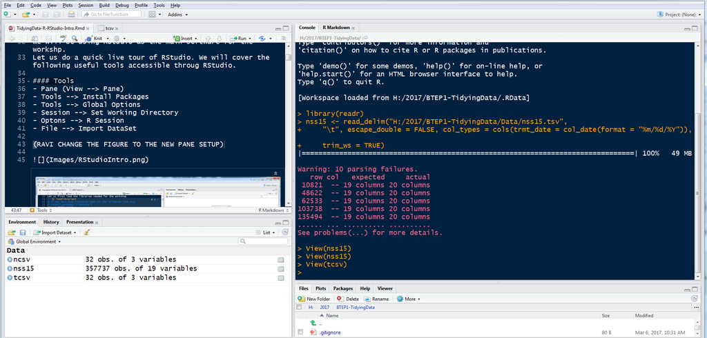

### Getting the data in R via RStudio

Let us introduce R/R-Studio Data Import with a Import Dataset and Command-line options

[figure not shown]

The following few lines will explain how to read in a data file via R command-line

Please note that we will be using **readr** function for this section. Note that **read_csv** is different than **read.csv**

- read_csv(), read_csv2()
- Note that read_csv2 and read_csv are same except for what options are default
- The returning objects from read_csv and read.csv are different (DF vs tibbles)
- Other read functions, read_tsv() and read_delim()